# P. sojae meta analysis

Austin McCoy

March 29 2022

# Objectives

Therefore, the objectives of this study are:

- Identify how pathotypes have changed over time in North America, Argentina, and China
  - Significant changes in complexity, as well as effective resistance genes over time (i.e. loss of Rps1c and Rps1k for resistance in North America)
- Identify regional virulence trends to aid breeding efforts
  - Compare pathotype diversity between states/provinces and countries

Packages needed for data exploration and analysis

```r
library(openxlsx)
library(plyr)
library(tidyverse)
library(DT)
library(hagis)
library(pander)
library(vegan)
library(ape)
library(ggsignif)
library(cowplot)
library(ellipse)
```

Reading in the various studies data

```r
path_to_file <- "./pathotype surveys data.xlsx" # path to the file with all the pathotype data in it
sheet_names <- openxlsx::getSheetNames(path_to_file) # acquiring sheet names, i.e. each studies name for the data found in each sheet
pathotype_data <- lapply(sheet_names, openxlsx::read.xlsx, xlsxFile=path_to_file) #acquiring the pathotype data from each sheet
names(pathotype_data) <- sheet_names # adding the sheets names to each sheet
#pathotype_data # lets see what it looks like, ~80k entries, not a good idea
```

Removing the data.frames which do not have pathotype data, so we just have study data to work with (i.e. surveys summary, Rps gene introduction dates, soybean differentials info, number strings for isolate name). This “list” will need to be updated if any new non-data sheets are added. Simply add the sheet name to be removed to the list, and it will be removed.

```r
pathotype_data[c("surveys summary","Rps gene introduction dates", "soybean differentials info", "number strings for isolate name")]=NULL
```

Combining the list of data.frames into one data.frame and renaming the new column “.id” to “study”

```r
pathotype_data_combined <- ldply(pathotype_data, rbind) # combining each data.frame
names(pathotype_data_combined)[names(pathotype_data_combined)==".id"] <- "study" # renaming the new ".id" column to "study"
#pathotype_data_combined # lets take an updated look at the data structure, ~80k entries, still not a good idea
```

OK, now we have all of the pathotype studies data in one data.frame. This will be updated whenever a new study is added to the excel sheet and this .Rmd file re-run, with no additional effort. The only caveat is if another excel sheet is added which needs to be removed. This excel sheet name will need to be included in the list within the chunk for “removing data.frames which do not have pathotype data”.

Lets take a look at the state/province, country, and years we have to work with in this interactive table

```r
study_state_prov_country_year <- unique(pathotype_data_combined[c("study","state_prov", "country", "year")]) # looking at the unique values for state/province, country and year by study
datatable(study_state_prov_country_year, rownames = FALSE, class = 'cell-border stripe', filter="top", options = list(pageLength = 5, scrollX=T, editable=FALSE) )
```

| study | state_prov | country | year |
| --- | --- | --- | --- |
| Buzzell 1977 | Ontario | Canada | 1975 |
| Buzzell 1977 | Ontario | Canada | 1974 |
| Buzzell 1977 | Ontario | Canada | 1976 |
| Buzzell 1977 | Ontario | Canada | 1973 |
| Anderson 1980 | Ontario | Canada | 1979 |
| Laviolette and Athow 1981 | Indiana | USA | 1973 |
| Laviolette and Athow 1981 | Indiana | USA | 1974 |
| Laviolette and Athow 1981 | Indiana | USA | 1975 |
| Laviolette and Athow 1981 | Indiana | USA | 1976 |
| Laviolette and Athow 1981 | Indiana | USA | 1977 |

[output cut: 116 more lines]

This information will be helpful in making a timeline of pathotype studies conducted. We have 126 timepoints from the 37 studies we are using

This is very informative, but a lot to look at. Lets break it down just by country and year to see if that makes it easier to look at/interpret. Again, using an interactive table.

```r
country_year <- unique(pathotype_data_combined[c("country", "year")]) # looking at the unique values for country and year
datatable(country_year, rownames = FALSE, class = 'cell-border stripe', filter="top", options = list(pageLength = 5, scrollX=T, editable=FALSE) )
```

| country | year |
| --- | --- |
| Canada | 1975 |
| Canada | 1974 |
| Canada | 1976 |
| Canada | 1973 |
| Canada | 1979 |
| USA | 1973 |
| USA | 1974 |
| USA | 1975 |
| USA | 1976 |
| USA | 1977 |

[output cut: 63 more lines]

```r
database_all_countries <- unique(pathotype_data_combined$country)
  database_all_countries
```

```
## [1] "Canada"    "USA"       "Australia" "Argentina" "China"     "Iran"
## [7] "Brazil"    "Uruguay"
```

```r
databse_total_isolates <- length(unique(pathotype_data_combined$Isolate))
databse_total_isolates
```

```
## [1] 7608
```

```r
database_total_studies <- unique(pathotype_data_combined$study)
database_total_studies
```

```
##  [1] "Buzzell 1977"                    "Anderson 1980"
##  [3] "Laviolette and Athow 1981"       "Schmitthenner 1994"
##  [5] "Anderson 1992"                   "Heritage 1993"
##  [7] "Barreto 1995"                    "Yang and Nelson 1996"
##  [9] "Abney 1997"                      "Kaitany 2001"
## [11] "Jian-Wei 2002"                   "Dorrance 2003"
## [13] "Zhu 2003"                        "Xiuhong 2003"
## [15] "Jackson 2004"                    "Malvick and Grunden 2004"
## [17] "Mohammadi 2007"                  "Nelson 2008"
## [19] "Robertson 2009"                  "Zhang 2010"
## [21] "Cui 2010"                        "Cui 2012"
## [23] "Costamilan 2013"                 "Xue 2015"
## [25] "Dorrance 2016"                   "Tian 2016"
## [27] "Agustina 2017"                   "Henriquez 2020"
## [29] "Grijalba et al 2020 B.A."        "Grijalba 2020 N&S pampas region"
## [31] "Grijalba 2014"                   "Hebb 2021"
## [33] "Chowdhury 2021"                  "McCoy 2021"
## [35] "Zhang 2021"                      "Tremblay 2021"
## [37] "Matthieson 2021 Iowa&Nebraska"
```

Now that we have an idea of the timeline of our sampling, lets calculate pathotype complexity by study so we can do analyses downstream looking at changes in pathotype complexity over time. Remember, this is using all of the genes tested in each study. for downstream analysis/visualization we may sub-sample down to only the widely deployed genes (Rps1a, Rps1c, Rps1k, Rps3a, Rps6).

To summarise the pathotype complexity of each isolate and study, we will use the *hagis* R package, for which we will need to set up the arguments used in *hagis*.

```r
hagis_args <- list(
  x = pathotype_data_combined,

  cutoff = 1,

  control = "rps",

  sample = "Isolate",

  gene = "Rps",

  perc_susc = "Susceptible.1"

)

#trying to get an average complexity output for each study

isolate_metadata <- pathotype_data_combined[c("Isolate","study" , "country", "year" )]

#complexity_by_study
complexity <- do.call(calculate_complexities, hagis_args) # this assigns complexity to each isolate but does not group by study
isolate_complexity <- complexity$indvidual_complexities # taking individual isolates data, not data summarized by complexity
names(isolate_complexity)[names(isolate_complexity)=="sample"] <- "Isolate" # renaming columns so we can merge data.frames
names(isolate_complexity)[names(isolate_complexity)=="N_samp"] <- "path_comp" # renaming columns so we can merge data.frames
isolate_complexity_metadata <- merge(isolate_complexity, isolate_metadata, by.x = c("Isolate"), by.y = c("Isolate"), all=F) # merging metadata and the complexity data
isolate_complexity_metadata # merged data.frame
```

```
##                                   Isolate path_comp         study country
##     1: 11-states_USA_Dorrance_2012-2013_1         6 Dorrance 2016     USA
##     2: 11-states_USA_Dorrance_2012-2013_1         6 Dorrance 2016     USA
##     3: 11-states_USA_Dorrance_2012-2013_1         6 Dorrance 2016     USA
##     4: 11-states_USA_Dorrance_2012-2013_1         6 Dorrance 2016     USA
##     5: 11-states_USA_Dorrance_2012-2013_1         6 Dorrance 2016     USA
##    ---
## 85682:         Zhejiang_China_Zhu_2000_82        12      Zhu 2003   China
## 85683:         Zhejiang_China_Zhu_2000_82        12      Zhu 2003   China
## 85684:         Zhejiang_China_Zhu_2000_82        12      Zhu 2003   China
## 85685:         Zhejiang_China_Zhu_2000_82        12      Zhu 2003   China
## 85686:         Zhejiang_China_Zhu_2000_82        12      Zhu 2003   China
##             year
##     1: 2012-2013
##     2: 2012-2013
##     3: 2012-2013
##     4: 2012-2013
##     5: 2012-2013
##    ---
## 85682:      2000
## 85683:      2000
## 85684:      2000
## 85685:      2000
## 85686:      2000
```

```r
study_mean_complexity <- isolate_complexity_metadata %>%
  group_by(study, country) %>%
  mutate() %>%
  summarize(mean_comp=mean(path_comp),
            sd_comp=sd(path_comp),
            study_n=length(unique(Isolate)))
   # this will give us the mean and standard deviation for pathotype complexities, as well as number of isolates tested by study.

pander(study_mean_complexity) # using pander for aesthetically appealing tables in R-markdown
```

| study | country | mean_comp | sd_comp | study_n |
| --- | --- | --- | --- | --- |
| Abney 1997 | USA | 2.498 | 1.398 | 303 |
| Agustina 2017 | Uruguay | 4.143 | 0.9173 | 14 |
| Anderson 1980 | Canada | 3.308 | 0.8223 | 52 |
| Anderson 1992 | Canada | 3.081 | 0.8729 | 669 |
| Barreto 1995 | Argentina | 1 | 0 | 46 |
| Buzzell 1977 | Canada | 4.5 | 1.054 | 200 |
| Chowdhury 2021 | USA | 5.146 | 2.595 | 171 |
| Costamilan 2013 | Brazil | 6.703 | 1.755 | 37 |
| Cui 2010 | China | 4.96 | 1.823 | 75 |
| Cui 2012 | China | 3.731 | 1.656 | 26 |
| Dorrance 2003 | USA | 5.564 | 2.984 | 287 |
| Dorrance 2016 | USA | 3.333 | 1.989 | 652 |
| Grijalba 2014 | Argentina | 3.47 | 2.705 | 193 |
| Grijalba 2020 N&S pampas region | Argentina | 4.366 | 1.523 | 93 |
| Grijalba et al 2020 B.A. | Argentina | 4.761 | 1.431 | 117 |
| Hebb 2021 | USA | 6.606 | 2.61 | 487 |
| Henriquez 2020 | Canada | 3.717 | 1.026 | 99 |
| Heritage 1993 | Australia | 1.024 | 0.1545 | 41 |
| Jackson 2004 | USA | 3.31 | 1.15 | 29 |
| Jian-Wei 2002 | China | 4.533 | 2.314 | 15 |
| Kaitany 2001 | USA | 7.192 | 3.027 | 78 |
| Laviolette and Athow 1981 | USA | 2.385 | 0.9957 | 1100 |
| Malvick and Grunden 2004 | USA | 3.914 | 1.951 | 116 |
| Matthieson 2021 Iowa&Nebraska | USA | 5.5 | 1.62 | 326 |
| McCoy 2021 | USA | 9.217 | 2.158 | 83 |
| Mohammadi 2007 | Iran | 1.225 | 0.4179 | 142 |
| Nelson 2008 | USA | 3.032 | 0.8776 | 157 |
| Robertson 2009 | USA | 4.097 | 1.555 | 31 |
| Schmitthenner 1994 | USA | 3.025 | 1.059 | 469 |
| Tian 2016 | China | 6.638 | 1.757 | 395 |
| Tremblay 2021 | Canada | 3.698 | 1.244 | 295 |
| Xiuhong 2003 | China | 2.905 | 1.661 | 42 |
| Xue 2015 | Canada | 4.19 | 1.268 | 253 |
| Yang and Nelson 1996 | USA | 2.022 | 0.9129 | 180 |
| Zhang 2010 | China | 1.438 | 0.8044 | 80 |
| Zhang 2021 | China | 4.017 | 1.717 | 172 |
| Zhu 2003 | China | 5.244 | 2.762 | 82 |

Complexity is very helpful in understanding HOW MANY genes a isolate or sampled population can overcome, however, knowing WHICH genes are not effective to manage *Phytophthora sojae* is still needed.

Virulence of sampled population on each tested Rps gene, by study, presented in an interactive table

```r
study_gene_summary <- pathotype_data_combined %>%
  group_by(study, Rps) %>%
  mutate() %>%
  summarize(N_pathogenic=sum(Susceptible.1),
            perc_pathogenic=((N_pathogenic)/(length(unique(Isolate)))*100))
# this will give us the number and percent of isolates pathogenic on each Rps gene tested, for each study we have.

datatable(study_gene_summary, rownames = FALSE, class = 'cell-border stripe', filter="top", options = list(pageLength = 5, scrollX=T, editable=FALSE) )
```

| study | Rps | N_pathogenic | perc_pathogenic |
| --- | --- | --- | --- |
| Abney 1997 | 1a | 204 | 67.3267326732673 |
| Abney 1997 | 1b | 45 | 14.8514851485149 |
| Abney 1997 | 1c | 35 | 11.5511551155116 |
| Abney 1997 | 1d | 49 | 16.1716171617162 |
| Abney 1997 | 1k | 50 | 16.5016501650165 |
| Abney 1997 | 3a | 22 | 7.26072607260726 |
| Abney 1997 | 6 | 50 | 16.5016501650165 |
| Abney 1997 | 7 | 302 | 99.6699669966997 |
| Abney 1997 | rps | 303 | 100 |
| Agustina 2017 | 1a | 3 | 21.4285714285714 |

[output cut: 406 more lines]

# Data Preparation

Looking at the sampling dates for each study we can identify which studies will be appropriate to group together and investigate virulence changes over time for this meta-analysis. There are, of course, some studies which we will not be able to use.

## Selection of Rps genes to use for this study

```r
rps_subset <- c("rps","1a","1b","1c","1d","1k","3a","6","7") # Rps genes we want to use for analyses

pathotype_data_combined_s9 <- pathotype_data_combined %>%
  subset(., Rps %in% rps_subset) # this will subset the combined dataset so that only the Rps genes we want to use in analyses will be present. All other isolate/gene phenotype data is discarded.

unique(pathotype_data_combined_s9$Rps) # double checking that only the isolates we want are in the subsetted dataset.
```

```
## [1] "rps" "1a"  "1b"  "1c"  "1d"  "3a"  "6"   "7"   "1k"
```

## USA timepoints (1990-1999, 2000-2013, 2013-2019)

```r
# USA 1990-1999 data
USA_1990_1999 <- pathotype_data_combined_s9 %>% # gathering all isolate data for the years 1990-1999 in the USA
  subset(country=="USA") %>%
  subset(year>=1990 & year<= 1999) %>%
  add_column(time_point="1990_1999", .after="study")



unique(USA_1990_1999$study) # double checking the correct studies were subset
```

```
## [1] "Schmitthenner 1994"   "Yang and Nelson 1996" "Abney 1997"
## [4] "Kaitany 2001"         "Dorrance 2003"        "Jackson 2004"
```

```r
unique(USA_1990_1999$year) # double checking our subsetting of years was correct
```

```
## [1] "1990"      "1991"      "1992-1993" "1994"      "1993"      "1993-1997"
## [7] "1997-1999" "1995-1998"
```

```r
USA_1990_1999_isolates <- length(unique(USA_1990_1999$Isolate)) # number of isolates we have for this time point
USA_1990_1999_isolates
```

```
## [1] 1116
```

```r
# USA 2000-2013

USA_2000_2013 <- pathotype_data_combined_s9 %>% # gathering all isolate data for the years 2000-2013 in the USA
  subset(country=="USA") %>%
  subset(year>=2000 & year<= 2013) %>%
  add_column(time_point="2000_2013", .after="study")

unique(USA_2000_2013$study)
```

```
## [1] "Malvick and Grunden 2004" "Nelson 2008"
## [3] "Robertson 2009"           "Dorrance 2016"
```

```r
unique(USA_2000_2013$year)
```

```
## [1] "2001-2002" "2002-2004" "2005"      "2012-2013"
```

```r
USA_2000_2013_isolates <- length(unique(USA_2000_2013$Isolate))
USA_2000_2013_isolates
```

```
## [1] 956
```

```r
# USA 2013-2019

USA_2013_2019 <- pathotype_data_combined_s9 %>% # gathering all isolate data for the years 2013-2019 in the USA
  subset(country=="USA") %>%
  subset(year>=2013 & year<= 2019) %>%
  add_column(time_point="2013_2019", .after="study") # A caveat, 2013 was used here so that Chowdhury 2021 (South Dakota) would be included in this group. Their sampling started in 2013 and continued through 2017. I believe it makes more sense to group Chowdhury with the other most recent studies in the U.S. for this temporal study, as they sampled many of the same years as other states.

unique(USA_2013_2019$study)
```

```
## [1] "Hebb 2021"                     "Chowdhury 2021"
## [3] "McCoy 2021"                    "Matthieson 2021 Iowa&Nebraska"
```

```r
unique(USA_2013_2019$year)
```

```
## [1] "2016-2018" "2013-2017" "2017"      "2016-2017"
```

```r
USA_2013_2019_isolates <- length(unique(USA_2013_2019$Isolate))
USA_2013_2019_isolates
```

```
## [1] 1067
```

```r
USA_final_data <- rbind(USA_1990_1999,USA_2000_2013,USA_2013_2019)
```

```r
# Argentina 1989-1999 data
ARG_1989_1999 <- pathotype_data_combined_s9 %>% # gathering all isolate data for the years 1990-1999 in Argentina
  subset(country=="Argentina") %>%
  subset(year>=1989 & year<= 1999) %>%
  add_column(time_point="1989_1999", .after="study") # Barreto 1995 started sampling in 1989 and ended in 1992, thus it was included in this timepoint.

unique(ARG_1989_1999$study) # double checking the correct studies were subset
```

```
## [1] "Barreto 1995"  "Grijalba 2014"
```

```r
unique(ARG_1989_1999$year) # double checking our subsetting of years was correct
```

```
## [1] "1989-1992" "1998"      "1999"
```

```r
ARG_1989_1999_isolates <- length(unique(ARG_1989_1999$Isolate)) # number of isolates we have for this time point
ARG_1989_1999_isolates
```

```
## [1] 174
```

```r
# Argentina 2000-2012 data
ARG_2000_2012 <- pathotype_data_combined_s9 %>% # gathering all isolate data for the years 2000-2013 in Argentina
  subset(country=="Argentina") %>%
  subset(year>=2000 & year<= 2012)  %>%
  add_column(time_point="2000_2012", .after="study")

unique(ARG_2000_2012$study)
```

```
## [1] "Grijalba 2014"
```

```r
unique(ARG_2000_2012$year)
```

```
## [1] "2000" "2002" "2004" "2003"
```

```r
ARG_2000_2012_isolates <- length(unique(ARG_2000_2012$Isolate))
ARG_2000_2012_isolates
```

```
## [1] 65
```

```r
# Argentina 2014-2019 data
ARG_2013_2019 <- pathotype_data_combined_s9 %>% # gathering all isolate data for the years 2013-2019 in Argentina
  subset(country=="Argentina") %>%
  subset(year>=2013 & year<= 2019) %>%
  add_column(time_point="2013_2019", .after="study")# Grijalba 2021 started sampling in 2013 and ended in 2015, thus it was included in this timepoint.

unique(ARG_2013_2019$study)
```

```
## [1] "Grijalba et al 2020 B.A."        "Grijalba 2020 N&S pampas region"
```

```r
unique(ARG_2013_2019$year)
```

```
## [1] "2014"      "2013-2014" "2013-2015" "2014-2015" "2015"      "2013"
```

```r
ARG_2013_2019_isolates <- length(unique(ARG_2013_2019$Isolate))
ARG_2013_2019_isolates
```

```
## [1] 210
```

```r
ARG_final_data <- rbind(ARG_1989_1999,ARG_2000_2012,ARG_2013_2019)

 #449 isolates data, without using "duprows" we would end up with 4 duplicated isolates data, all from 2013 (in both the 2000-2013 and 2014-2019 timepoints). This way allows us to use all data from isolates sampled in "2013" and those sampled in "2013-2014" or "2013-2015", which we would like to have in the 2014_2019 dataset. Setting the lower limit of the 2014-2019 timepoint to 2014 would result in the loss of ~100 isolates data, since they did not have a specific year sampled, but were instead given as a range (i.e.2013-2014 and 2013-2015). This seemed the best of both worlds so we could use all of the data as accurately as possible.
```

## Canada timepoints (2000-2013, 2014-2019)

```r
# Canada 2000-2013 data
CAN_2000_2013 <- pathotype_data_combined_s9 %>% # gathering all isolate data for the years 2000-2013 in Canada
  subset(country=="Canada") %>%
  subset(year>=2000 & year<= 2013) %>%
  add_column(time_point="2000_2013", .after="study")

unique(CAN_2000_2013$study)
```

```
## [1] "Xue 2015"
```

```r
unique(CAN_2000_2013$year)
```

```
## [1] "2011" "2012" "2010"
```

```r
CAN_2000_2013_isolates <- length(unique(CAN_2000_2013$Isolate))
CAN_2000_2013_isolates
```

```
## [1] 253
```

```r
# Canada 2014-2019 data
CAN_2014_2019 <- pathotype_data_combined_s9 %>% # gathering all isolate data for the years 2013-2019 in Canada
  subset(country=="Canada") %>%
  subset(year>=2014 & year<= 2019) %>%
  add_column(time_point="2014_2019", .after="study")

unique(CAN_2014_2019$study)
```

```
## [1] "Henriquez 2020" "Tremblay 2021"
```

```r
unique(CAN_2014_2019$year)
```

```
## [1] "2014"      "2016"      "2017"      "2016-2019"
```

```r
CAN_2014_2019_isolates <- length(unique(CAN_2014_2019$Isolate))
CAN_2014_2019_isolates
```

```
## [1] 394
```

```r
CAN_final_data <- rbind(CAN_2000_2013,CAN_2014_2019)
```

```r
CHI_1990_1999 <- pathotype_data_combined_s9 %>% # gathering all isolate data for the years 1990-1999 in China
  subset(country=="China") %>%
  subset(year>=1990 & year<= 1999) %>%
  add_column(time_point="1990_1999", .after="study")

unique(CHI_1990_1999$study) # double checking the correct studies were subset
```

```
## [1] "Jian-Wei 2002" "Zhu 2003"      "Xiuhong 2003"
```

```r
unique(CHI_1990_1999$year) # double checking our subsetting of years was correct
```

```
## [1] "1990-1999" "1996"      "1997"      "1999"      "1998"
```

```r
CHI_1990_1999_isolates <- length(unique(CHI_1990_1999$Isolate)) # number of isolates we have for this time point
CHI_1990_1999_isolates
```

```
## [1] 97
```

```r
CHINA_2000_2013 <- pathotype_data_combined_s9 %>% # gathering all isolate data for the years 2000-2013 in China
  subset(country=="China") %>%
  subset(year>=2000 & year<= 2013) %>%
  add_column(time_point="2000_2013", .after="study")

unique(CHINA_2000_2013$study)
```

```
## [1] "Zhu 2003"   "Zhang 2010" "Cui 2010"   "Cui 2012"   "Tian 2016"
## [6] "Zhang 2021"
```

```r
unique(CHINA_2000_2013$year)
```

```
## [1] "2000"      "2001"      "2005"      "2006"      "2007"      "2007-2008"
## [7] "2011-2015" "2007-2015"
```

```r
CHINA_2000_2013_isolates <- length(unique(CHINA_2000_2013$Isolate))
CHINA_2000_2013_isolates
```

```
## [1] 790
```

```r
CHINA_2014_2019 <- pathotype_data_combined_s9 %>% # gathering all isolate data for the years 2013-2019 in Canada
  subset(country=="China") %>%
  subset(year>=2014 & year<= 2019) %>%
  add_column(time_point="2014_2019", .after="study")

unique(CHINA_2014_2019$study)
```

```
## character(0)
```

```r
unique(CHINA_2014_2019$year)
```

```
## character(0)
```

```r
CHINA_2014_2019_isolates <- length(unique(CHINA_2014_2019$Isolate))
CHINA_2014_2019_isolates
```

```
## [1] 0
```

```r
CHI_final_data <- rbind(CHI_1990_1999,CHINA_2000_2013,CHINA_2014_2019)
```

# Data Analysis

A reminder, the objectives of this study are:

- Identify how pathotypes have changed over time in North America, Argentina, and China
  - Significant changes in complexity, as well as effective resistance genes over time (i.e. loss of Rps1c and Rps1k for resistance in North America? Just certain areas?)
- Identify regional virulence trends to aid breeding efforts
  - Compare pathotype diversity between states/provinces and countries

## Temporal Comparison of Pathotype Complexity

### USA

```r
USA_hagis_args <- list(
  x = USA_final_data,

  cutoff = 1,

  control = "rps",

  sample = "Isolate",

  gene = "Rps",

  perc_susc = "Susceptible.1"

)

USA_isolate_metadata <- USA_final_data[c("Isolate","study" , "year","time_point" )]

USA_complexity <- do.call(calculate_complexities, USA_hagis_args)
USA_isolate_complexity <- USA_complexity$indvidual_complexities # taking individual isolates data, not data summarized by complexity
names(USA_isolate_complexity)[names(USA_isolate_complexity)=="sample"] <- "Isolate" # renaming columns so we can merge data.frames
names(USA_isolate_complexity)[names(USA_isolate_complexity)=="N_samp"] <- "path_comp" # renaming columns so we can merge data.frames
USA_isolate_complexity_metadata <- merge(USA_isolate_complexity, USA_isolate_metadata, by.x = c("Isolate"), by.y = c("Isolate"), all=F) # merging metadata and the complexity data
USA_isolate_complexity_metadata
```

```
##                                        Isolate path_comp          study
##     1:      11-states_USA_Dorrance_2012-2013_1         6  Dorrance 2016
##     2:      11-states_USA_Dorrance_2012-2013_1         6  Dorrance 2016
##     3:      11-states_USA_Dorrance_2012-2013_1         6  Dorrance 2016
##     4:      11-states_USA_Dorrance_2012-2013_1         6  Dorrance 2016
##     5:      11-states_USA_Dorrance_2012-2013_1         6  Dorrance 2016
##    ---
## 28114: South_Dakota_USA_Chowdhury_2013-2017_99         5 Chowdhury 2021
## 28115: South_Dakota_USA_Chowdhury_2013-2017_99         5 Chowdhury 2021
## 28116: South_Dakota_USA_Chowdhury_2013-2017_99         5 Chowdhury 2021
## 28117: South_Dakota_USA_Chowdhury_2013-2017_99         5 Chowdhury 2021
## 28118: South_Dakota_USA_Chowdhury_2013-2017_99         5 Chowdhury 2021
##             year time_point
##     1: 2012-2013  2000_2013
##     2: 2012-2013  2000_2013
##     3: 2012-2013  2000_2013
##     4: 2012-2013  2000_2013
##     5: 2012-2013  2000_2013
##    ---
## 28114: 2013-2017  2013_2019
## 28115: 2013-2017  2013_2019
## 28116: 2013-2017  2013_2019
## 28117: 2013-2017  2013_2019
## 28118: 2013-2017  2013_2019
```

```r
USA_timepoints_mean_complexity <- USA_isolate_complexity_metadata %>%
  group_by(time_point) %>%
  mutate() %>%
  summarize(mean_comp=mean(path_comp),
            sd_comp=sd(path_comp),
            n=length(unique(Isolate)))
   # this will give us the mean and standard deviation for pathotype complexities, as well as number of isolates tested by time point.

pander(USA_timepoints_mean_complexity) # using pander for aesthetically appealing tables in R-markdown
```

| time_point | mean_comp | sd_comp | n |
| --- | --- | --- | --- |
| 1990_1999 | 3.023 | 1.627 | 1115 |
| 2000_2013 | 3.127 | 1.692 | 956 |
| 2013_2019 | 4.892 | 1.454 | 1067 |

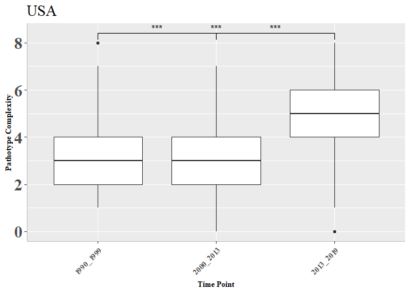

```r
# Lets look at this data using a boxplot
USA_complexity_box <- ggplot(USA_isolate_complexity_metadata, aes(x=time_point, y=path_comp)) +
  geom_boxplot() +
  geom_signif(comparisons = list(c("1990_1999", "2000_2013"),c("1990_1999", "2013_2019"),c("2000_2013","2013_2019")),
              test = "t.test",
              map_signif_level = TRUE) +
theme(axis.text.x = element_text(size = 10, face = "bold", angle=45, hjust=1, family = "serif"),
                     axis.text.y = element_text(size = 20, face = "bold", family = "serif"),
                     axis.title.x = element_text(size = 10, face = "bold", family = "serif"),
                     axis.title.y = element_text(size = 10, face = "bold", family = "serif"),
                     axis.line.x = element_line(colour = 'gray', size=0.5, linetype='solid'),
                     axis.line.y = element_line(colour = 'gray', size=0.5, linetype='solid'),
                     legend.text = element_text(size = 10, face = "bold", family = "serif"),
                     legend.key = element_blank(),
                     legend.title = element_text(size = 10, face="bold", family = "serif"),
                     legend.position = "right",
                     strip.text.x = element_text(size = 15, face = "bold", family = "serif"),
                     title = element_text(size = 16, family = "serif")) +
                      ggtitle("USA") +
  xlab("Time Point") + ylab("Pathotype Complexity")+
  ggtitle("USA")
USA_complexity_box # looks like there was an increase in pathotype complexity at the latest timepoint, as compared to the 1990-1999 and 2000-2013 timepoints. But we dont know if they are significant or not, so lets test that next.
```

```r
# testing significance between USA timepoints pathotype complexity - Welchs t.test
# Just to double check the significance tested and applied in ggpplot-ggsignif

# between 1990-1999 and 2000-2013 timepoints
USA_complexity_data_90_99_00_13 <- USA_isolate_complexity_metadata %>%
  subset(time_point!="2013_2019")
USA_sig_90_99_00_13 <- t.test(path_comp~time_point, data = USA_complexity_data_90_99_00_13)
USA_sig_90_99_00_13
```

```
##
##  Welch Two Sample t-test
##
## data:  path_comp by time_point
## t = -4.2506, df = 17890, p-value = 2.142e-05
## alternative hypothesis: true difference in means between group 1990_1999 and group 2000_2013 is not equal to 0
## 95 percent confidence interval:
##  -0.15208947 -0.05609117
## sample estimates:
## mean in group 1990_1999 mean in group 2000_2013
##                3.023403                3.127493
```

```r
# between 1990-1999 and 2014-2019 timepoints
USA_complexity_data_90_99_14_19 <- USA_isolate_complexity_metadata %>%
  subset(time_point!="2000_2013")
USA_sig_90_99_14_19 <- t.test(path_comp~time_point, data = USA_complexity_data_90_99_14_19)
USA_sig_90_99_14_19
```

```
##
##  Welch Two Sample t-test
##
## data:  path_comp by time_point
## t = -84.712, df = 19436, p-value < 2.2e-16
## alternative hypothesis: true difference in means between group 1990_1999 and group 2013_2019 is not equal to 0
## 95 percent confidence interval:
##  -1.911365 -1.824914
## sample estimates:
## mean in group 1990_1999 mean in group 2013_2019
##                3.023403                4.891542
```

```r
# between 2000-2013 and 2014-2019 timepoints
USA_complexity_data_00_13_14_19 <- USA_isolate_complexity_metadata %>%
  subset(time_point!="1990_1999")
USA_sig_00_13_14_19 <- t.test(path_comp~time_point, data = USA_complexity_data_00_13_14_19)
USA_sig_00_13_14_19
```

```
##
##  Welch Two Sample t-test
##
## data:  path_comp by time_point
## t = -74.92, df = 17003, p-value < 2.2e-16
## alternative hypothesis: true difference in means between group 2000_2013 and group 2013_2019 is not equal to 0
## 95 percent confidence interval:
##  -1.810201 -1.717897
## sample estimates:
## mean in group 2000_2013 mean in group 2013_2019
##                3.127493                4.891542
```

### Argentina

```r
ARG_hagis_args <- list(
  x = ARG_final_data,

  cutoff = 1,

  control = "rps",

  sample = "Isolate",

  gene = "Rps",

  perc_susc = "Susceptible.1"

)

ARG_isolate_metadata <- ARG_final_data[c("Isolate","study" , "year","time_point" )]

ARG_complexity <- do.call(calculate_complexities, ARG_hagis_args)
ARG_isolate_complexity <- ARG_complexity$indvidual_complexities # taking individual isolates data, not data summarized by complexity
names(ARG_isolate_complexity)[names(ARG_isolate_complexity)=="sample"] <- "Isolate" # renaming columns so we can merge data.frames
names(ARG_isolate_complexity)[names(ARG_isolate_complexity)=="N_samp"] <- "path_comp" # renaming columns so we can merge data.frames
ARG_isolate_complexity_metadata <- merge(ARG_isolate_complexity, ARG_isolate_metadata, by.x = c("Isolate"), by.y = c("Isolate"), all=F) # merging metadata and the complexity data
ARG_isolate_complexity_metadata
```

```
##                                          Isolate path_comp         study
##    1: Buenos_Aires_Argentina_Barreto_1989-1992_1         1  Barreto 1995
##    2: Buenos_Aires_Argentina_Barreto_1989-1992_1         1  Barreto 1995
##    3: Buenos_Aires_Argentina_Barreto_1989-1992_1         1  Barreto 1995
##    4: Buenos_Aires_Argentina_Barreto_1989-1992_1         1  Barreto 1995
##    5: Buenos_Aires_Argentina_Barreto_1989-1992_1         1  Barreto 1995
##   ---
## 4037:       Santa_Fe_Argentina_Grijalba_2004_183         6 Grijalba 2014
## 4038:       Santa_Fe_Argentina_Grijalba_2004_183         6 Grijalba 2014
## 4039:       Santa_Fe_Argentina_Grijalba_2004_183         6 Grijalba 2014
## 4040:       Santa_Fe_Argentina_Grijalba_2004_183         6 Grijalba 2014
## 4041:       Santa_Fe_Argentina_Grijalba_2004_183         6 Grijalba 2014
##            year time_point
##    1: 1989-1992  1989_1999
##    2: 1989-1992  1989_1999
##    3: 1989-1992  1989_1999
##    4: 1989-1992  1989_1999
##    5: 1989-1992  1989_1999
##   ---
## 4037:      2004  2000_2012
## 4038:      2004  2000_2012
## 4039:      2004  2000_2012
## 4040:      2004  2000_2012
## 4041:      2004  2000_2012
```

```r
ARG_timepoints_mean_complexity <- ARG_isolate_complexity_metadata %>%
  group_by(time_point) %>%
  mutate() %>%
  summarize(mean_comp=mean(path_comp),
            sd_comp=sd(path_comp),
            n=length(unique(Isolate))) # this will give us the mean and standard deviation for pathotype complexities, as well as number of isolates tested by time point.

pander(ARG_timepoints_mean_complexity) # using pander for aesthetically appealing tables in R-markdown
```

| time_point | mean_comp | sd_comp | n |
| --- | --- | --- | --- |
| 1989_1999 | 2.264 | 1.414 | 174 |
| 2000_2012 | 2.692 | 1.728 | 65 |
| 2013_2019 | 4.586 | 1.485 | 210 |

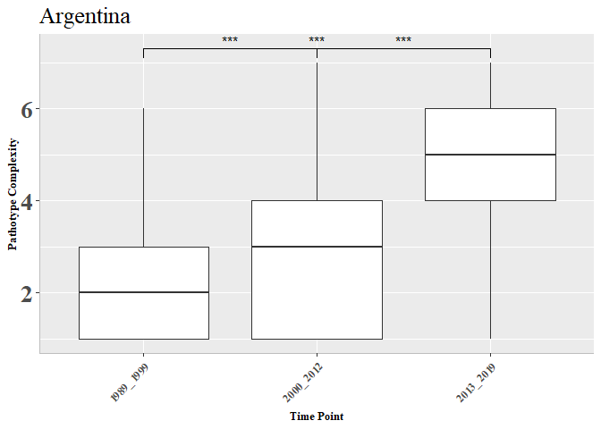

```r
# Lets look at this data using a boxplot
ARG_complexity_box <- ggplot(ARG_isolate_complexity_metadata, aes(x=time_point, y=path_comp)) +
  geom_boxplot() +
  geom_signif(comparisons = list(c("1989_1999", "2000_2012"),c("1989_1999", "2013_2019"),c("2000_2012","2013_2019")),
              test = "t.test",
              map_signif_level = TRUE) +
  theme(axis.text.x = element_text(size = 10, face = "bold", angle=45, hjust=1, family = "serif"),
                     axis.text.y = element_text(size = 20, face = "bold", family = "serif"),
                     axis.title.x = element_text(size = 10, face = "bold", family = "serif"),
                     axis.title.y = element_text(size = 10, face = "bold", family = "serif"),
                     axis.line.x = element_line(colour = 'gray', size=0.5, linetype='solid'),
                     axis.line.y = element_line(colour = 'gray', size=0.5, linetype='solid'),
                     legend.text = element_text(size = 10, face = "bold", family = "serif"),
                     legend.key = element_blank(),
                     legend.title = element_text(size = 10, face="bold", family = "serif"),
                     legend.position = "right",
                     strip.text.x = element_text(size = 15, face = "bold", family = "serif"),
                     title = element_text(size = 16, family = "serif")) +
                      ggtitle("USA") +
  xlab("Time Point") + ylab("Pathotype Complexity")+
  ggtitle("Argentina")
ARG_complexity_box # looks like there was an increase in pathotype complexity at the latest timepoint, as compared to the 1990-1999 and 2000-2013 timepoints. But we dont know if they are significant or not, so lets test that next.
```

```r
# testing significance between Argentina timepoints pathotype complexity - Welchs t.test

# between 1989-1999 and 2000-2012 timepoints
ARG_complexity_data_89_99_00_12 <- ARG_isolate_complexity_metadata %>%
  subset(time_point!="2013_2019")
ARG_sig_89_99_00_12 <- t.test(path_comp~time_point, data = ARG_complexity_data_89_99_00_12)
ARG_sig_89_99_00_12
```

```
##
##  Welch Two Sample t-test
##
## data:  path_comp by time_point
## t = -5.356, df = 891.88, p-value = 1.083e-07
## alternative hypothesis: true difference in means between group 1989_1999 and group 2000_2012 is not equal to 0
## 95 percent confidence interval:
##  -0.5847531 -0.2711266
## sample estimates:
## mean in group 1989_1999 mean in group 2000_2012
##                2.264368                2.692308
```

```r
# between 1989-1999 and 2013-2019 timepoints
ARG_complexity_data_89_99_13_19 <- ARG_isolate_complexity_metadata %>%
  subset(time_point!="2000_2012")
ARG_sig_89_99_13_19 <- t.test(path_comp~time_point, data = ARG_complexity_data_89_99_13_19)
ARG_sig_89_99_13_19
```

```
##
##  Welch Two Sample t-test
##
## data:  path_comp by time_point
## t = -46.952, df = 3388, p-value < 2.2e-16
## alternative hypothesis: true difference in means between group 1989_1999 and group 2013_2019 is not equal to 0
## 95 percent confidence interval:
##  -2.418284 -2.224409
## sample estimates:
## mean in group 1989_1999 mean in group 2013_2019
##                2.264368                4.585714
```

```r
# between 2000-2012 and 2013-2019 timepoints
ARG_complexity_data_00_12_13_19 <- ARG_isolate_complexity_metadata %>%
  subset(time_point!="1989_1999")
ARG_sig_00_12_13_19 <- t.test(path_comp~time_point, data = ARG_complexity_data_00_12_13_19)
ARG_sig_00_12_13_19
```

```
##
##  Welch Two Sample t-test
##
## data:  path_comp by time_point
## t = -23.905, df = 867.43, p-value < 2.2e-16
## alternative hypothesis: true difference in means between group 2000_2012 and group 2013_2019 is not equal to 0
## 95 percent confidence interval:
##  -2.048865 -1.737948
## sample estimates:
## mean in group 2000_2012 mean in group 2013_2019
##                2.692308                4.585714
```

### Canada

```r
CAN_hagis_args <- list(
  x = CAN_final_data,

  cutoff = 1,

  control = "rps",

  sample = "Isolate",

  gene = "Rps",

  perc_susc = "Susceptible.1"

)

CAN_isolate_metadata <- CAN_final_data[c("Isolate","study" , "year","time_point" )]

CAN_complexity <- do.call(calculate_complexities, CAN_hagis_args)
CAN_isolate_complexity <- CAN_complexity$indvidual_complexities # taking individual isolates data, not data summarized by complexity
names(CAN_isolate_complexity)[names(CAN_isolate_complexity)=="sample"] <- "Isolate" # renaming columns so we can merge data.frames
names(CAN_isolate_complexity)[names(CAN_isolate_complexity)=="N_samp"] <- "path_comp" # renaming columns so we can merge data.frames
CAN_isolate_complexity_metadata <- merge(CAN_isolate_complexity, CAN_isolate_metadata, by.x = c("Isolate"), by.y = c("Isolate"), all=F) # merging metadata and the complexity data
CAN_isolate_complexity_metadata
```

```
##                                   Isolate path_comp          study      year
##    1:    Manitoba_Canada_Henriquez_2014_1         5 Henriquez 2020      2014
##    2:    Manitoba_Canada_Henriquez_2014_1         5 Henriquez 2020      2014
##    3:    Manitoba_Canada_Henriquez_2014_1         5 Henriquez 2020      2014
##    4:    Manitoba_Canada_Henriquez_2014_1         5 Henriquez 2020      2014
##    5:    Manitoba_Canada_Henriquez_2014_1         5 Henriquez 2020      2014
##   ---
## 5524: Quebec_Canada_Tremblay_2016-2019_30         5  Tremblay 2021 2016-2019
## 5525: Quebec_Canada_Tremblay_2016-2019_30         5  Tremblay 2021 2016-2019
## 5526: Quebec_Canada_Tremblay_2016-2019_30         5  Tremblay 2021 2016-2019
## 5527: Quebec_Canada_Tremblay_2016-2019_30         5  Tremblay 2021 2016-2019
## 5528: Quebec_Canada_Tremblay_2016-2019_30         5  Tremblay 2021 2016-2019
##       time_point
##    1:  2014_2019
##    2:  2014_2019
##    3:  2014_2019
##    4:  2014_2019
##    5:  2014_2019
##   ---
## 5524:  2014_2019
## 5525:  2014_2019
## 5526:  2014_2019
## 5527:  2014_2019
## 5528:  2014_2019
```

```r
CAN_timepoints_mean_complexity <- CAN_isolate_complexity_metadata %>%
  group_by(time_point) %>%
  mutate() %>%
  summarize(mean_comp=mean(path_comp),
            sd_comp=sd(path_comp),
            n=length(unique(Isolate))) # this will give us the mean and standard deviation for pathotype complexities, as well as number of isolates tested by time point.

pander(CAN_timepoints_mean_complexity) # using pander for aesthetically appealing tables in R-markdown
```

| time_point | mean_comp | sd_comp | n |
| --- | --- | --- | --- |
| 2000_2013 | 4.19 | 1.268 | 253 |
| 2014_2019 | 3.703 | 1.188 | 394 |

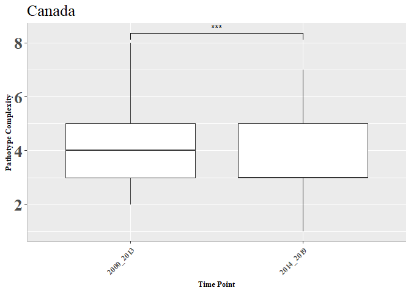

```r
# Lets look at this data using a boxplot
CAN_complexity_box <- ggplot(CAN_isolate_complexity_metadata, aes(x=time_point, y=path_comp)) +
  geom_boxplot() +
  geom_signif(comparisons = list(c("2000_2013","2014_2019")),
              test = "t.test",
              map_signif_level = TRUE) +
  theme(axis.text.x = element_text(size = 10, face = "bold", angle=45, hjust=1, family = "serif"),
                     axis.text.y = element_text(size = 20, face = "bold", family = "serif"),
                     axis.title.x = element_text(size = 10, face = "bold", family = "serif"),
                     axis.title.y = element_text(size = 10, face = "bold", family = "serif"),
                     axis.line.x = element_line(colour = 'gray', size=0.5, linetype='solid'),
                     axis.line.y = element_line(colour = 'gray', size=0.5, linetype='solid'),
                     legend.text = element_text(size = 10, face = "bold", family = "serif"),
                     legend.key = element_blank(),
                     legend.title = element_text(size = 10, face="bold", family = "serif"),
                     legend.position = "right",
                     strip.text.x = element_text(size = 15, face = "bold", family = "serif"),
                     title = element_text(size = 16, family = "serif")) +
                      ggtitle("USA") +
  xlab("Time Point") + ylab("Pathotype Complexity")+
  ggtitle("Canada")
CAN_complexity_box # looks like there was a slight decrease in pathotype complexity at the latest timepoint, as compared to the 2000-2013 timepoint. But we dont know if they are significant or not, so lets test that next.
```

```r
# testing significance between Canada timepoints pathotype complexity - Welchs t.test

# between 1990-1999 and 2000-2013 timepoints
#CAN_complexity_data_90_99_00_13 <- CAN_isolate_complexity_metadata %>%
#  subset(time_point!="2014_2019")
#CAN_sig_90_99_00_13 <- t.test(path_comp~time_point, data = CAN_complexity_data_90_99_00_13)
#CAN_sig_90_99_00_13

# between 1990-1999 and 2014-2019 timepoints
#CAN_complexity_data_90_99_14_19 <- CAN_isolate_complexity_metadata %>%
#  subset(time_point!="2000_2013")
#CAN_sig_90_99_14_19 <- t.test(path_comp~time_point, data = CAN_complexity_data_90_99_14_19)
#CAN_sig_90_99_14_19

# between 2000-2013 and 2014-2019 timepoints
CAN_complexity_data_00_13_14_19 <- CAN_isolate_complexity_metadata %>%
  subset(time_point!="1990_1999")
CAN_sig_00_13_14_19 <- t.test(path_comp~time_point, data = CAN_complexity_data_00_13_14_19)
CAN_sig_00_13_14_19
```

```
##
##  Welch Two Sample t-test
##
## data:  path_comp by time_point
## t = 14.397, df = 4691.3, p-value < 2.2e-16
## alternative hypothesis: true difference in means between group 2000_2013 and group 2014_2019 is not equal to 0
## 95 percent confidence interval:
##  0.4200346 0.5524603
## sample estimates:
## mean in group 2000_2013 mean in group 2014_2019
##                4.189723                3.703476
```

### China

```r
CHI_hagis_args <- list(
  x = CHI_final_data,

  cutoff = 1,

  control = "rps",

  sample = "Isolate",

  gene = "Rps",

  perc_susc = "Susceptible.1"

)

CHI_isolate_metadata <- CHI_final_data[c("Isolate","study" , "year","time_point" )]

CHI_complexity <- do.call(calculate_complexities, CHI_hagis_args)
CHI_isolate_complexity <- CHI_complexity$indvidual_complexities # taking individual isolates data, not data summarized by complexity
names(CHI_isolate_complexity)[names(CHI_isolate_complexity)=="sample"] <- "Isolate" # renaming columns so we can merge data.frames
names(CHI_isolate_complexity)[names(CHI_isolate_complexity)=="N_samp"] <- "path_comp" # renaming columns so we can merge data.frames
CHI_isolate_complexity_metadata <- merge(CHI_isolate_complexity, CHI_isolate_metadata, by.x = c("Isolate"), by.y = c("Isolate"), all=F) # merging metadata and the complexity data
CHI_isolate_complexity_metadata
```

```
##                          Isolate path_comp    study year time_point
##    1:    Anhui_China_Zhu_1999_51         4 Zhu 2003 1999  1990_1999
##    2:    Anhui_China_Zhu_1999_51         4 Zhu 2003 1999  1990_1999
##    3:    Anhui_China_Zhu_1999_51         4 Zhu 2003 1999  1990_1999
##    4:    Anhui_China_Zhu_1999_51         4 Zhu 2003 1999  1990_1999
##    5:    Anhui_China_Zhu_1999_51         4 Zhu 2003 1999  1990_1999
##   ---
## 7904: Zhejiang_China_Zhu_2000_82         8 Zhu 2003 2000  2000_2013
## 7905: Zhejiang_China_Zhu_2000_82         8 Zhu 2003 2000  2000_2013
## 7906: Zhejiang_China_Zhu_2000_82         8 Zhu 2003 2000  2000_2013
## 7907: Zhejiang_China_Zhu_2000_82         8 Zhu 2003 2000  2000_2013
## 7908: Zhejiang_China_Zhu_2000_82         8 Zhu 2003 2000  2000_2013
```

```r
CHI_timepoints_mean_complexity <- CHI_isolate_complexity_metadata %>%
  group_by(time_point) %>%
  mutate() %>%
  summarize(mean_comp=mean(path_comp),
            sd_comp=sd(path_comp),
            n=length(unique(Isolate))) # this will give us the mean and standard deviation for pathotype complexities, as well as number of isolates tested by time point.

pander(CHI_timepoints_mean_complexity) # using pander for aesthetically appealing tables in R-markdown
```

| time_point | mean_comp | sd_comp | n |
| --- | --- | --- | --- |
| 1990_1999 | 2.928 | 1.784 | 97 |
| 2000_2013 | 3.244 | 1.756 | 790 |

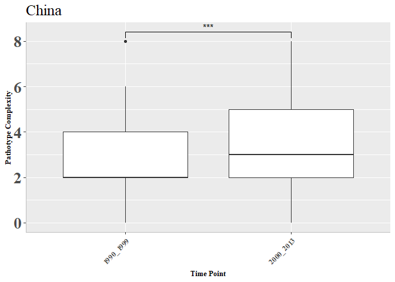

```r
# Lets look at this data using a boxplot
CHI_complexity_box <- ggplot(CHI_isolate_complexity_metadata, aes(x=time_point, y=path_comp)) +
  geom_boxplot() +
  geom_signif(comparisons = list(c("1990_1999", "2000_2013")),
              test = "t.test",
              map_signif_level = TRUE) +
  theme(axis.text.x = element_text(size = 10, face = "bold", angle=45, hjust=1, family = "serif"),
                     axis.text.y = element_text(size = 20, face = "bold", family = "serif"),
                     axis.title.x = element_text(size = 10, face = "bold", family = "serif"),
                     axis.title.y = element_text(size = 10, face = "bold", family = "serif"),
                     axis.line.x = element_line(colour = 'gray', size=0.5, linetype='solid'),
                     axis.line.y = element_line(colour = 'gray', size=0.5, linetype='solid'),
                     legend.text = element_text(size = 10, face = "bold", family = "serif"),
                     legend.key = element_blank(),
                     legend.title = element_text(size = 10, face="bold", family = "serif"),
                     legend.position = "right",
                     strip.text.x = element_text(size = 15, face = "bold", family = "serif"),
                     title = element_text(size = 16, family = "serif")) +
                      ggtitle("USA") +
  xlab("Time Point") + ylab("Pathotype Complexity")+
  ggtitle("China")
CHI_complexity_box
```

```r
# testing significance between China timepoints pathotype complexity - Welchs t.test

# between 1990-1999 and 2000-2013 timepoints
CHI_complexity_data_90_99_00_13 <- CHI_isolate_complexity_metadata %>%
  subset(time_point!="2014_2019")
CHI_sig_90_99_00_13 <- t.test(path_comp~time_point, data = CHI_complexity_data_90_99_00_13)
CHI_sig_90_99_00_13
```

```
##
##  Welch Two Sample t-test
##
## data:  path_comp by time_point
## t = -4.9474, df = 1092.3, p-value = 8.703e-07
## alternative hypothesis: true difference in means between group 1990_1999 and group 2000_2013 is not equal to 0
## 95 percent confidence interval:
##  -0.4416471 -0.1908136
## sample estimates:
## mean in group 1990_1999 mean in group 2000_2013
##                2.927835                3.244065
```

```r
# between 1990-1999 and 2014-2019 timepoints
#CHI_complexity_data_90_99_14_19 <- CHI_isolate_complexity_metadata %>%
#  subset(time_point!="2000_2013")
#CHI_sig_90_99_14_19 <- t.test(path_comp~time_point, data = CHI_complexity_data_90_99_14_19)
#CHI_sig_90_99_14_19

# between 2000-2013 and 2014-2019 timepoints
#CHI_complexity_data_00_13_14_19 <- CHI_isolate_complexity_metadata %>%
#  subset(time_point!="1990_1999")
#CHI_sig_00_13_14_19 <- t.test(path_comp~time_point, data = CHI_complexity_data_00_13_14_19)
#CHI_sig_00_13_14_19
```

# Summary graphic of pathotype complexity over time for each country

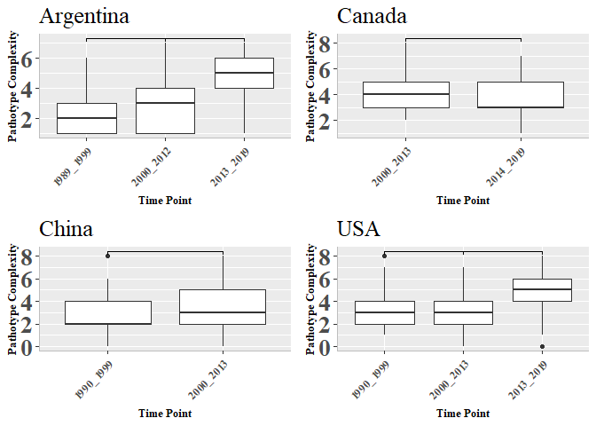

```r
combined_path_comp_temporal <- plot_grid(ARG_complexity_box,CAN_complexity_box,CHI_complexity_box,USA_complexity_box)
combined_path_comp_temporal
```

# Temporal comparison of Pathotype diversity

## USA

```r
#USA_diversity_1990_1999 <- USA_final_data
```

# Temporal comparison of Rps gene efficacy

## USA

```r
USA_timepoint_gene_summary <- USA_final_data %>%
  group_by(time_point, Rps) %>%
  mutate() %>%
  summarize(N_pathogenic=sum(Susceptible.1),
            perc_pathogenic=((N_pathogenic)/(length(unique(Isolate)))*100))
```

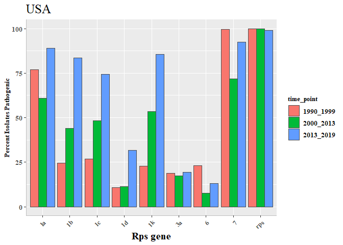

```r
# this will give us the number and percent of isolates pathogenic on each Rps gene tested, for each study we have.

plot <- ggplot(USA_timepoint_gene_summary, aes(Rps, perc_pathogenic, fill=time_point))
plot <- plot + geom_bar(stat = "identity", position = 'dodge', col = '#4d4d4d')
USA_rps_eff_tim <- plot + theme_gray() +
  theme(axis.text.x = element_text(size = 10, face = "bold", angle=45, hjust=1, family = "serif"),
                     axis.text.y = element_text(size = 10, face = "bold", family = "serif"),
                     axis.title.x = element_text(size = 15, face = "bold", family = "serif"),
                     axis.title.y = element_text(size = 10, face = "bold", family = "serif"),
                     axis.line.x = element_line(colour = 'gray', size=0.5, linetype='solid'),
                     axis.line.y = element_line(colour = 'gray', size=0.5, linetype='solid'),
                     legend.text = element_text(size = 10, face = "bold", family = "serif"),
                     legend.key = element_blank(),
                     legend.title = element_text(size = 10, face="bold", family = "serif"),
                     legend.position = "right",
                     strip.text.x = element_text(size = 15, face = "bold", family = "serif"),
                     title = element_text(size = 16, family = "serif")) +
                      ggtitle("USA") +
  xlab("Rps gene") + ylab("Percent Isolates Pathogenic")
USA_rps_eff_tim
```

## Argentina

```r
ARG_timepoint_gene_summary <- ARG_final_data %>%
  group_by(time_point, Rps) %>%
  mutate() %>%
  summarize(N_pathogenic=sum(Susceptible.1),
            perc_pathogenic=((N_pathogenic)/(length(unique(Isolate)))*100))
```

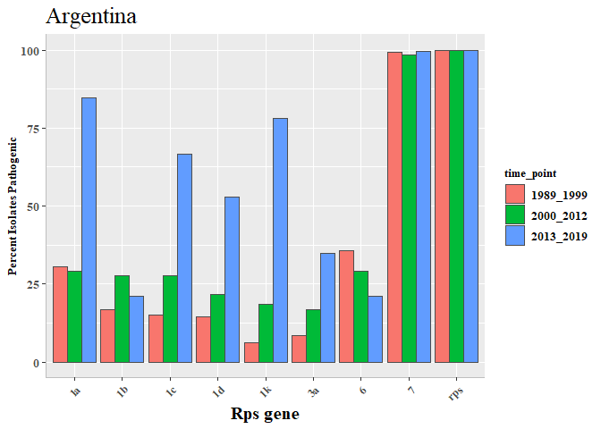

```r
# this will give us the number and percent of isolates pathogenic on each Rps gene tested, for each study we have.

plot <- ggplot(ARG_timepoint_gene_summary, aes(Rps, perc_pathogenic, fill=time_point))
plot <- plot + geom_bar(stat = "identity", position = 'dodge', col = '#4d4d4d')
ARG_rps_eff_tim <- plot + theme_gray() +
  theme(axis.text.x = element_text(size = 10, face = "bold", angle=45, hjust=1, family = "serif"),
                     axis.text.y = element_text(size = 10, face = "bold", family = "serif"),
                     axis.title.x = element_text(size = 15, face = "bold", family = "serif"),
                     axis.title.y = element_text(size = 10, face = "bold", family = "serif"),
                     axis.line.x = element_line(colour = 'gray', size=0.5, linetype='solid'),
                     axis.line.y = element_line(colour = 'gray', size=0.5, linetype='solid'),
                     legend.text = element_text(size = 10, face = "bold", family = "serif"),
                     legend.key = element_blank(),
                     legend.title = element_text(size = 10, face="bold", family = "serif"),
                     legend.position = "right",
                     strip.text.x = element_text(size = 15, face = "bold", family = "serif"),
                     title = element_text(size = 16, family = "serif")) +
                      ggtitle("Argentina") +
  xlab("Rps gene") + ylab("Percent Isolates Pathogenic")
ARG_rps_eff_tim
```

## Canada

#### (double check that this is correct, I expected a higher percent pathogenic for Rps1k, even though Rps1a and Rps1c is “lost”)

```r
CAN_timepoint_gene_summary <- CAN_final_data %>%
  group_by(time_point, Rps) %>%
  mutate() %>%
  summarize(N_pathogenic=sum(Susceptible.1),
            perc_pathogenic=((N_pathogenic)/(length(unique(Isolate)))*100))
```

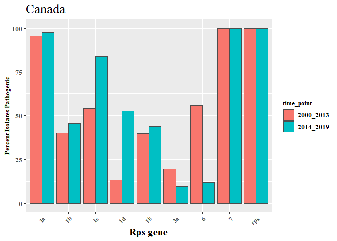

```r
# this will give us the number and percent of isolates pathogenic on each Rps gene tested, for each study we have.

plot <- ggplot(CAN_timepoint_gene_summary, aes(Rps, perc_pathogenic, fill=time_point))
plot <- plot + geom_bar(stat = "identity", position = 'dodge', col = '#4d4d4d')
CAN_rps_eff_tim <- plot + theme_gray() +
  theme(axis.text.x = element_text(size = 10, face = "bold", angle=45, hjust=1, family = "serif"),
                     axis.text.y = element_text(size = 10, face = "bold", family = "serif"),
                     axis.title.x = element_text(size = 15, face = "bold", family = "serif"),
                     axis.title.y = element_text(size = 10, face = "bold", family = "serif"),
                     axis.line.x = element_line(colour = 'gray', size=0.5, linetype='solid'),
                     axis.line.y = element_line(colour = 'gray', size=0.5, linetype='solid'),
                     legend.text = element_text(size = 10, face = "bold", family = "serif"),
                     legend.key = element_blank(),
                     legend.title = element_text(size = 10, face="bold", family = "serif"),
                     legend.position = "right",
                     strip.text.x = element_text(size = 15, face = "bold", family = "serif"),
                     title = element_text(size = 16, family = "serif")) +
                      ggtitle("Canada") +
  xlab("Rps gene") + ylab("Percent Isolates Pathogenic")
CAN_rps_eff_tim
```

## China

```r
CHI_timepoint_gene_summary <- CHI_final_data %>%
  group_by(time_point, Rps) %>%
  mutate() %>%
  summarize(N_pathogenic=sum(Susceptible.1),
            perc_pathogenic=((N_pathogenic)/(length(unique(Isolate)))*100))
```

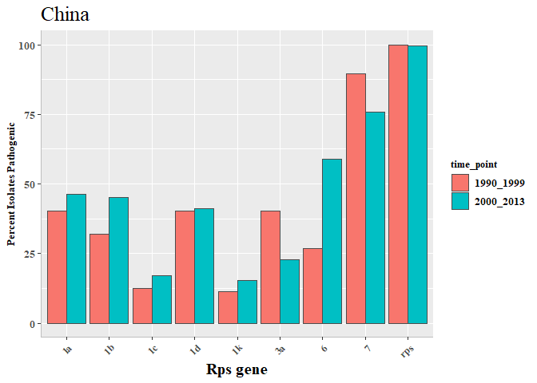

```r
# this will give us the number and percent of isolates pathogenic on each Rps gene tested, for each study we have.

plot <- ggplot(CHI_timepoint_gene_summary, aes(Rps, perc_pathogenic, fill=time_point))
plot <- plot + geom_bar(stat = "identity", position = 'dodge', col = '#4d4d4d')
CHI_rps_eff_tim <- plot + theme_gray() +
  theme(axis.text.x = element_text(size = 10, face = "bold", angle=45, hjust=1, family = "serif"),
                     axis.text.y = element_text(size = 10, face = "bold", family = "serif"),
                     axis.title.x = element_text(size = 15, face = "bold", family = "serif"),
                     axis.title.y = element_text(size = 10, face = "bold", family = "serif"),
                     axis.line.x = element_line(colour = 'gray', size=0.5, linetype='solid'),
                     axis.line.y = element_line(colour = 'gray', size=0.5, linetype='solid'),
                     legend.text = element_text(size = 10, face = "bold", family = "serif"),
                     legend.key = element_blank(),
                     legend.title = element_text(size = 10, face="bold", family = "serif"),
                     legend.position = "right",
                     strip.text.x = element_text(size = 15, face = "bold", family = "serif"),
                     title = element_text(size = 16, family = "serif")) +
                      ggtitle("China") +
  xlab("Rps gene") + ylab("Percent Isolates Pathogenic")
CHI_rps_eff_tim
```

# Combined summary figure on resistance-gene efficacy

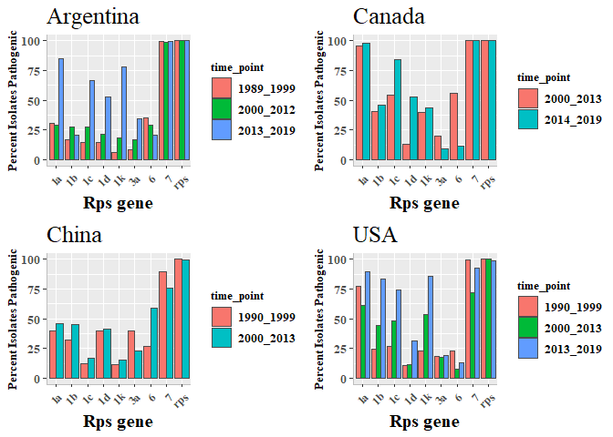

```r
# bar-graphs on resistance-gene efficacy
combined_gene_eff_temporal <- plot_grid(ARG_rps_eff_tim,CAN_rps_eff_tim,CHI_rps_eff_tim,USA_rps_eff_tim)
combined_gene_eff_temporal
```

To determine if/how the sampled populations pathotype structure has changed over time, we will use Principal Coordinate analysis (PCoA) to first visualize each regions pathotype structure by timepoint to see if they are distinct. We will then use a Permutational Multivariate Analysis of Variance (PERMANOVA) to determine if the populations pathotype structure is significantly different at each timepoint. Lastly, we will use a Discriminant Analysis of Principal Components (DAPC) to determine which genes specifically are driving the differences in each timepoints sampled populations pathotype structure.

From these comparison analyses we will be able to identify 1.) **If** the sampled *P. sojae* populations pathotype structure have changed significantly over time, and 2.) **which genes** the sampled populations have adapted to thus driving the differences we (may) see between timepoints.

So, without further ado 🎼 Lets get down to business… 🎼

# Temporal comparison of the sampled populations pathotype structure

To do these analyses we will need to take our regional data sets and turn them each into a data matrix. We can do this using the *hagis* R package function `create_binary_matrix()`. This will allow for downstream analyses using packages like `vegan` and `ape`.

## USA virulence matrix

```r
# we are going to remove the isolates now that have a gene-subsetted complexity of 0
#to do this we will combine the USA_isolate_complexity file and the USA_final_data file, then filter, keeping only the isolates that do not have a pathotype complexity of 0

USA_final_data_comp <- merge(USA_final_data, USA_isolate_complexity, by.x = c("Isolate"), by.y = c("Isolate"), all=F)

USA_final_data_comp_no0 <- USA_final_data_comp %>%
                    subset(path_comp!="0") %>% # remove those isolates with 0 pathotype complexity
                    subset(Rps!="rps") # remove the susceptible control, seeing if this will fix my error as all isolates would have virulence on this differential
# creating the binary virulence matrix to be used for PCoA

USA_vir_matrix <- create_binary_matrix(x = USA_final_data_comp_no0,

  cutoff = 1,

  control = "rps",

  sample = "Isolate",

  gene = "Rps",

  perc_susc = "Susceptible.1") # this creates a binary matrix of virulence, but has no metadata associated
```

## USA calculating Jaccard distances

```r
# Jaccard distances on USA_vir_matrix
USA_vir_jaccard <- vegdist(USA_vir_matrix, "jaccard", na.rm = TRUE)
#any(is.complex(USA_vir_jaccard))
```

## USA Principal Coordinates Analysis

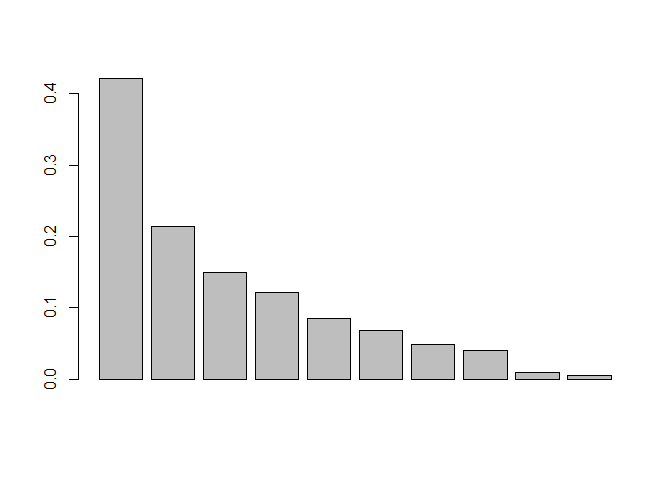

```r
#USA_vir_pcoa <- cmdscale(USA_vir_jaccard, eig = TRUE) # this is the PCoA, using the stats package instead of ape as ape was throwing errors with our large dataset.
#test <- pcoscaled(USA_vir_jaccard)
USA_pca <- pcoa(USA_vir_jaccard)
#plot( )
# calculate the percentage of variation that each Principle Coordinate accounts for
USA_Axis1.percent <- USA_pca$values$Relative_eig[[1]]*100 # Dimension (Axis 1 (PcoA1)) 42.10312%
USA_Axis2.percent <- USA_pca$values$Relative_eig[[2]]*100 # Dimension (Axis 2 (PcoA2)) 21.40556%
USA_Axis3.percent <- USA_pca$values$Relative_eig[[3]]*100 #
USA_Axis4.percent <- USA_pca$values$Relative_eig[[4]]*100
USA_Axis5.percent <- USA_pca$values$Relative_eig[[5]]*100
USA_Axis6.percent <- USA_pca$values$Relative_eig[[6]]*100
USA_Axis7.percent <- USA_pca$values$Relative_eig[[7]]*100
USA_Axis8.percent <- USA_pca$values$Relative_eig[[8]]*100


barplot(USA_pca$values$Relative_eig[1:10]) # looks like the first two principal components account for nearly 65% of the variance, so we will just use those
```

```r
USA_pca_data <- data.frame(sample = rownames(USA_pca$vectors),
                                      X = USA_pca$vectors[, 1],
                                      Y = USA_pca$vectors[, 2])
```

## adding metadata to PCoA

```r
names(USA_pca_data)[names(USA_pca_data)=="sample"] <- "Isolate" # renaming columns so we can merge data.frames
USA_pca_metadata <- left_join(USA_pca_data, USA_isolate_metadata, by = "Isolate")
head(USA_pca_metadata)
```

```
##                              Isolate          X          Y         study
## 1 11-states_USA_Dorrance_2012-2013_1 -0.2461147 0.01112101 Dorrance 2016
## 2 11-states_USA_Dorrance_2012-2013_1 -0.2461147 0.01112101 Dorrance 2016
## 3 11-states_USA_Dorrance_2012-2013_1 -0.2461147 0.01112101 Dorrance 2016
## 4 11-states_USA_Dorrance_2012-2013_1 -0.2461147 0.01112101 Dorrance 2016
## 5 11-states_USA_Dorrance_2012-2013_1 -0.2461147 0.01112101 Dorrance 2016
## 6 11-states_USA_Dorrance_2012-2013_1 -0.2461147 0.01112101 Dorrance 2016
##        year time_point
## 1 2012-2013  2000_2013
## 2 2012-2013  2000_2013
## 3 2012-2013  2000_2013
## 4 2012-2013  2000_2013
## 5 2012-2013  2000_2013
## 6 2012-2013  2000_2013
```

## Plotting USA PCoA data

```r
str(USA_pca_metadata)
```

```
## 'data.frame':    27884 obs. of  6 variables:
##  $ Isolate   : chr  "11-states_USA_Dorrance_2012-2013_1" "11-states_USA_Dorrance_2012-2013_1" "11-states_USA_Dorrance_2012-2013_1" "11-states_USA_Dorrance_2012-2013_1" ...
##  $ X         : num  -0.246 -0.246 -0.246 -0.246 -0.246 ...
##  $ Y         : num  0.0111 0.0111 0.0111 0.0111 0.0111 ...
##  $ study     : chr  "Dorrance 2016" "Dorrance 2016" "Dorrance 2016" "Dorrance 2016" ...
##  $ year      : chr  "2012-2013" "2012-2013" "2012-2013" "2012-2013" ...
##  $ time_point: chr  "2000_2013" "2000_2013" "2000_2013" "2000_2013" ...
```

```r
print(unique(USA_pca_metadata$time_point))
```

```
## [1] "2000_2013" "1990_1999" "2013_2019"
```

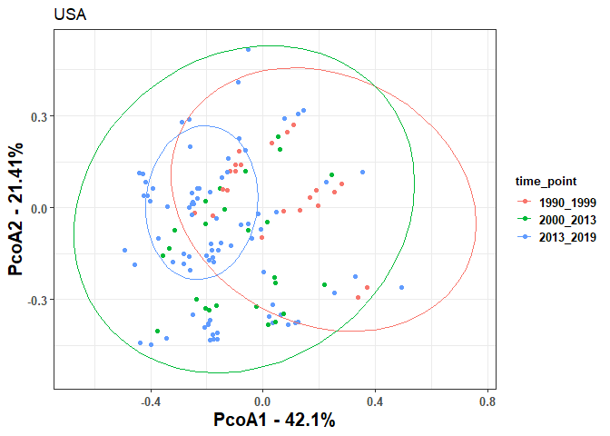

```r
USA_pcoa_plot <- ggplot(data = USA_pca_metadata, aes(x = X, y = Y)) +
  geom_point(aes(colour = time_point)) +
  xlab(paste("PcoA1 - ", round(USA_Axis1.percent,2), "%", sep = "")) +
  ylab(paste("PcoA2 - ", round(USA_Axis2.percent,2), "%", sep = "")) +
  theme_bw() +
  theme(
    axis.title.x = element_text(face = "bold", size = 15),
    axis.title.y = element_text(face = "bold", size = 15),
    axis.text = element_text(face = "bold", size = 10),
    legend.title = element_text(face = "bold", size = 10),
    legend.text = element_text(face = "bold", size = 10),
    legend.key.size = unit(1, 'lines')
  ) +
  stat_ellipse(aes(x = X, y = Y, color=time_point, group=time_point), level = 0.95) +
  ggtitle("USA")

USA_pcoa_plot
```

## Argentina virulence matrix

```r
# we are going to remove the isolates now that have a gene-subsetted complexity of 0

ARG_final_data_comp <- merge(ARG_final_data, ARG_isolate_complexity, by.x = c("Isolate"), by.y = c("Isolate"), all=F)

ARG_final_data_comp_no0 <- ARG_final_data_comp %>%
                    subset(path_comp!="0") %>% # remove those isolates with 0 pathotype complexity
                    subset(Rps!="rps") # remove the susceptible control

str(ARG_final_data_comp_no0)
```

```
## 'data.frame':    3592 obs. of  12 variables:
##  $ Isolate      : chr  "Buenos_Aires_Argentina_Barreto_1989-1992_1" "Buenos_Aires_Argentina_Barreto_1989-1992_1" "Buenos_Aires_Argentina_Barreto_1989-1992_1" "Buenos_Aires_Argentina_Barreto_1989-1992_1" ...
##  $ study        : chr  "Barreto 1995" "Barreto 1995" "Barreto 1995" "Barreto 1995" ...
##  $ time_point   : chr  "1989_1999" "1989_1999" "1989_1999" "1989_1999" ...
##  $ author       : chr  "Barreto" "Barreto" "Barreto" "Barreto" ...
##  $ state_prov   : chr  "Buenos_Aires" "Buenos_Aires" "Buenos_Aires" "Buenos_Aires" ...
##  $ country      : chr  "Argentina" "Argentina" "Argentina" "Argentina" ...
##  $ sample       : chr  "field_plant" "field_plant" "field_plant" "field_plant" ...
##  $ year         : chr  "1989-1992" "1989-1992" "1989-1992" "1989-1992" ...
##  $ race         : chr  "1" "1" "1" "1" ...
##  $ Rps          : chr  "1a" "1b" "1c" "1d" ...
##  $ Susceptible.1: num  0 0 0 0 0 0 0 1 0 0 ...
##  $ path_comp    : num  1 1 1 1 1 1 1 1 1 1 ...
```

```r
# creating the binary virulence matrix to be used for PCoA

ARG_vir_matrix <- create_binary_matrix(x = ARG_final_data_comp_no0,

  cutoff = 1,

  control = "rps",

  sample = "Isolate",

  gene = "Rps",

  perc_susc = "Susceptible.1") # this creates a binary matrix of virulence, but has no metadata associated.
```

## Argentina calculating Jaccard distances

```r
# Jaccard distances on USA_vir_matrix
ARG_vir_jaccard <- vegdist(ARG_vir_matrix, "jaccard", na.rm = TRUE)
#any(is.complex(USA_vir_jaccard))
```

## Argentina Principal Coordinates Analysis

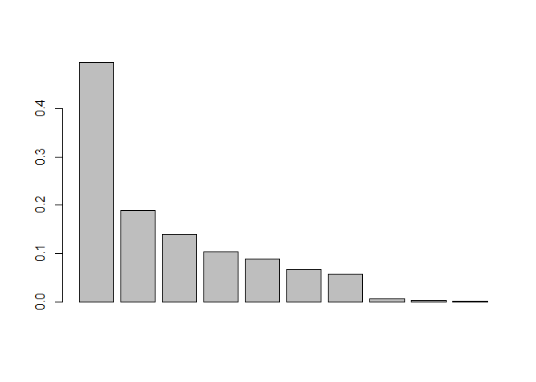

```r
ARG_pca <- pcoa(ARG_vir_jaccard)

# calculate the percentage of variation that each Principle Coordinate accounts for
ARG_Axis1.percent <- ARG_pca$values$Relative_eig[[1]]*100 # Dimension (Axis 1 (PcoA1)) 49.56%
ARG_Axis2.percent <- ARG_pca$values$Relative_eig[[2]]*100 # Dimension (Axis 2 (PcoA2)) 18.89%
ARG_Axis3.percent <- ARG_pca$values$Relative_eig[[3]]*100 #
ARG_Axis4.percent <- ARG_pca$values$Relative_eig[[4]]*100
ARG_Axis5.percent <- ARG_pca$values$Relative_eig[[5]]*100
ARG_Axis6.percent <- ARG_pca$values$Relative_eig[[6]]*100
ARG_Axis7.percent <- ARG_pca$values$Relative_eig[[7]]*100
ARG_Axis8.percent <- ARG_pca$values$Relative_eig[[8]]*100


barplot(ARG_pca$values$Relative_eig[1:10]) #
```

```r
ARG_pca_data <- data.frame(sample = rownames(ARG_pca$vectors),
                                      X = ARG_pca$vectors[, 1],
                                      Y = ARG_pca$vectors[, 2])
```

## adding metadata to PCoA

```r
names(ARG_pca_data)[names(ARG_pca_data)=="sample"] <- "Isolate" # renaming columns so we can merge data.frames
ARG_pca_metadata <- left_join(ARG_pca_data, ARG_isolate_metadata, by = "Isolate")
head(ARG_pca_metadata)
```

```
##                                      Isolate          X           Y
## 1 Buenos_Aires_Argentina_Barreto_1989-1992_1 -0.4551485 -0.07841181
## 2 Buenos_Aires_Argentina_Barreto_1989-1992_1 -0.4551485 -0.07841181
## 3 Buenos_Aires_Argentina_Barreto_1989-1992_1 -0.4551485 -0.07841181
## 4 Buenos_Aires_Argentina_Barreto_1989-1992_1 -0.4551485 -0.07841181
## 5 Buenos_Aires_Argentina_Barreto_1989-1992_1 -0.4551485 -0.07841181
## 6 Buenos_Aires_Argentina_Barreto_1989-1992_1 -0.4551485 -0.07841181
##          study      year time_point
## 1 Barreto 1995 1989-1992  1989_1999
## 2 Barreto 1995 1989-1992  1989_1999
## 3 Barreto 1995 1989-1992  1989_1999
## 4 Barreto 1995 1989-1992  1989_1999
## 5 Barreto 1995 1989-1992  1989_1999
## 6 Barreto 1995 1989-1992  1989_1999
```

## Plotting Argentina PCoA data

```r
str(ARG_pca_metadata)
```

```
## 'data.frame':    4041 obs. of  6 variables:
##  $ Isolate   : chr  "Buenos_Aires_Argentina_Barreto_1989-1992_1" "Buenos_Aires_Argentina_Barreto_1989-1992_1" "Buenos_Aires_Argentina_Barreto_1989-1992_1" "Buenos_Aires_Argentina_Barreto_1989-1992_1" ...
##  $ X         : num  -0.455 -0.455 -0.455 -0.455 -0.455 ...
##  $ Y         : num  -0.0784 -0.0784 -0.0784 -0.0784 -0.0784 ...
##  $ study     : chr  "Barreto 1995" "Barreto 1995" "Barreto 1995" "Barreto 1995" ...
##  $ year      : chr  "1989-1992" "1989-1992" "1989-1992" "1989-1992" ...
##  $ time_point: chr  "1989_1999" "1989_1999" "1989_1999" "1989_1999" ...
```

```r
print(unique(ARG_pca_metadata$time_point))
```

```
## [1] "1989_1999" "2000_2012" "2013_2019"
```

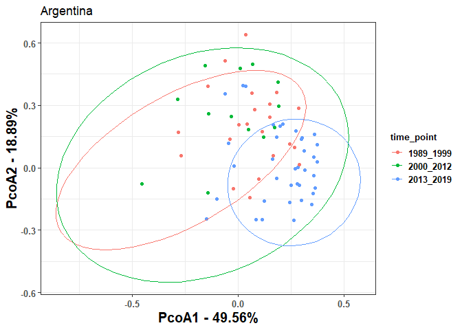

```r
ARG_pcoa_plot <- ggplot(data = ARG_pca_metadata, aes(x = X, y = Y)) +
  geom_point(aes(colour = time_point)) +
  xlab(paste("PcoA1 - ", round(ARG_Axis1.percent,2), "%", sep = "")) +
  ylab(paste("PcoA2 - ", round(ARG_Axis2.percent,2), "%", sep = "")) +
  theme_bw() +
  theme(
    axis.title.x = element_text(face = "bold", size = 15),
    axis.title.y = element_text(face = "bold", size = 15),
    axis.text = element_text(face = "bold", size = 10),
    legend.title = element_text(face = "bold", size = 10),
    legend.text = element_text(face = "bold", size = 10),
    legend.key.size = unit(1, 'lines')
  ) +
  stat_ellipse(aes(x = X, y = Y, color=time_point, group=time_point), level = 0.95) +
  ggtitle("Argentina")

ARG_pcoa_plot
```

## Canada virulence matrix

```r
# we are going to remove the isolates now that have a gene-subsetted complexity of 0

CAN_final_data_comp <- merge(CAN_final_data, CAN_isolate_complexity, by.x = c("Isolate"), by.y = c("Isolate"), all=F)

CAN_final_data_comp_no0 <- CAN_final_data_comp %>%
                    subset(path_comp!="0") %>% # remove those isolates with 0 pathotype complexity
                    subset(Rps!="rps") # remove the susceptible control

str(CAN_final_data_comp_no0)
```

```
## 'data.frame':    4881 obs. of  12 variables:
##  $ Isolate      : chr  "Manitoba_Canada_Henriquez_2014_1" "Manitoba_Canada_Henriquez_2014_1" "Manitoba_Canada_Henriquez_2014_1" "Manitoba_Canada_Henriquez_2014_1" ...
##  $ study        : chr  "Henriquez 2020" "Henriquez 2020" "Henriquez 2020" "Henriquez 2020" ...
##  $ time_point   : chr  "2014_2019" "2014_2019" "2014_2019" "2014_2019" ...
##  $ author       : chr  "Henriquez" "Henriquez" "Henriquez" "Henriquez" ...
##  $ state_prov   : chr  "Manitoba" "Manitoba" "Manitoba" "Manitoba" ...
##  $ country      : chr  "Canada" "Canada" "Canada" "Canada" ...
##  $ sample       : chr  "field_sample" "field_sample" "field_sample" "field_sample" ...
##  $ year         : chr  "2014" "2014" "2014" "2014" ...
##  $ race         : chr  NA NA NA NA ...
##  $ Rps          : chr  "1a" "1b" "1c" "1d" ...
##  $ Susceptible.1: num  1 1 1 0 1 0 0 1 1 1 ...
##  $ path_comp    : num  5 5 5 5 5 5 5 5 5 5 ...
```

```r
# creating the binary virulence matrix to be used for PCoA

CAN_vir_matrix <- create_binary_matrix(x = CAN_final_data_comp_no0,

  cutoff = 1,

  control = "rps",

  sample = "Isolate",

  gene = "Rps",

  perc_susc = "Susceptible.1") # this creates a binary matrix of virulence, but has no metadata associated.
```

## Canada calculating Jaccard distances

```r
# Jaccard distances on USA_vir_matrix
CAN_vir_jaccard <- vegdist(CAN_vir_matrix, "jaccard", na.rm = TRUE)
#any(is.complex(USA_vir_jaccard))
```

## Canada Principal Coordinates Analysis

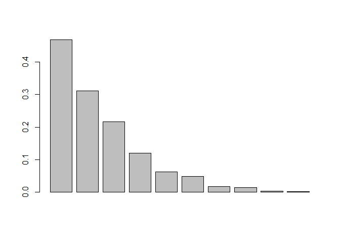

```r
CAN_pca <- pcoa(CAN_vir_jaccard)

# calculate the percentage of variation that each Principle Coordinate accounts for
CAN_Axis1.percent <- CAN_pca$values$Relative_eig[[1]]*100 # Dimension (Axis 1 (PcoA1)) 46.90%
CAN_Axis2.percent <- CAN_pca$values$Relative_eig[[2]]*100 # Dimension (Axis 2 (PcoA2)) 31.14%
CAN_Axis3.percent <- CAN_pca$values$Relative_eig[[3]]*100 #
CAN_Axis4.percent <- CAN_pca$values$Relative_eig[[4]]*100
CAN_Axis5.percent <- CAN_pca$values$Relative_eig[[5]]*100
CAN_Axis6.percent <- CAN_pca$values$Relative_eig[[6]]*100
CAN_Axis7.percent <- CAN_pca$values$Relative_eig[[7]]*100
CAN_Axis8.percent <- CAN_pca$values$Relative_eig[[8]]*100


barplot(CAN_pca$values$Relative_eig[1:10]) #
```

```r
CAN_pca_data <- data.frame(sample = rownames(CAN_pca$vectors),
                                      X = CAN_pca$vectors[, 1],
                                      Y = CAN_pca$vectors[, 2])
```

## adding metadata to PCoA

```r
names(CAN_pca_data)[names(CAN_pca_data)=="sample"] <- "Isolate" # renaming columns so we can merge data.frames
CAN_pca_metadata <- left_join(CAN_pca_data, CAN_isolate_metadata, by = "Isolate")
head(CAN_pca_metadata)
```

```
##                            Isolate          X          Y          study year
## 1 Manitoba_Canada_Henriquez_2014_1 -0.2221873 -0.1557069 Henriquez 2020 2014
## 2 Manitoba_Canada_Henriquez_2014_1 -0.2221873 -0.1557069 Henriquez 2020 2014
## 3 Manitoba_Canada_Henriquez_2014_1 -0.2221873 -0.1557069 Henriquez 2020 2014
## 4 Manitoba_Canada_Henriquez_2014_1 -0.2221873 -0.1557069 Henriquez 2020 2014
## 5 Manitoba_Canada_Henriquez_2014_1 -0.2221873 -0.1557069 Henriquez 2020 2014
## 6 Manitoba_Canada_Henriquez_2014_1 -0.2221873 -0.1557069 Henriquez 2020 2014
##   time_point
## 1  2014_2019
## 2  2014_2019
## 3  2014_2019
## 4  2014_2019
## 5  2014_2019
## 6  2014_2019
```

## Plotting Canada PCoA data

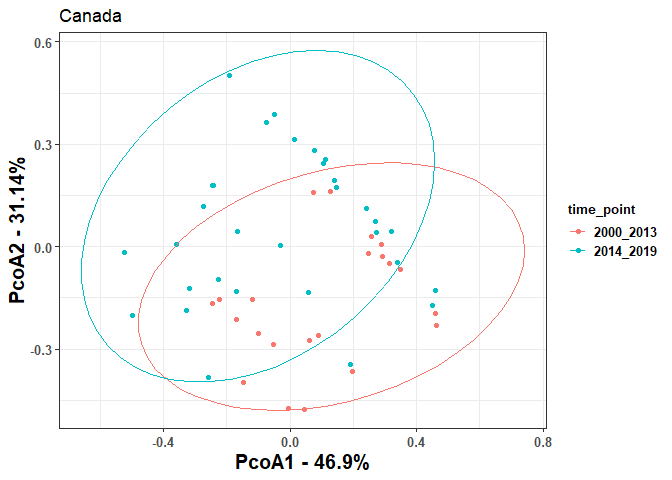

```r
CAN_pcoa_plot <- ggplot(data = CAN_pca_metadata, aes(x = X, y = Y)) +
  geom_point(aes(colour = time_point)) +
  xlab(paste("PcoA1 - ", round(CAN_Axis1.percent,2), "%", sep = "")) +
  ylab(paste("PcoA2 - ", round(CAN_Axis2.percent,2), "%", sep = "")) +
  theme_bw() +
  theme(
    axis.title.x = element_text(face = "bold", size = 15),
    axis.title.y = element_text(face = "bold", size = 15),
    axis.text = element_text(face = "bold", size = 10),
    legend.title = element_text(face = "bold", size = 10),
    legend.text = element_text(face = "bold", size = 10),
    legend.key.size = unit(1, 'lines')
  ) +
  stat_ellipse(aes(x = X, y = Y, color=time_point, group=time_point), level = 0.95) +
  ggtitle("Canada")

CAN_pcoa_plot
```

## China virulence matrix

```r
# we are going to remove the isolates now that have a gene-subsetted complexity of 0

CHI_final_data_comp <- merge(CHI_final_data, CHI_isolate_complexity, by.x = c("Isolate"), by.y = c("Isolate"), all=F)

CHI_final_data_comp_no0 <- CHI_final_data_comp %>%
                    subset(path_comp!="0") %>% # remove those isolates with 0 pathotype complexity
                    subset(Rps!="rps") # remove the susceptible control

str(CHI_final_data_comp_no0)
```

```
## 'data.frame':    6832 obs. of  12 variables:
##  $ Isolate      : chr  "Anhui_China_Zhu_1999_51" "Anhui_China_Zhu_1999_51" "Anhui_China_Zhu_1999_51" "Anhui_China_Zhu_1999_51" ...
##  $ study        : chr  "Zhu 2003" "Zhu 2003" "Zhu 2003" "Zhu 2003" ...
##  $ time_point   : chr  "1990_1999" "1990_1999" "1990_1999" "1990_1999" ...
##  $ author       : chr  "Zhu" "Zhu" "Zhu" "Zhu" ...
##  $ state_prov   : chr  "Anhui" "Anhui" "Anhui" "Anhui" ...
##  $ country      : chr  "China" "China" "China" "China" ...
##  $ sample       : chr  "field_plant" "field_plant" "field_plant" "field_plant" ...
##  $ year         : chr  "1999" "1999" "1999" "1999" ...
##  $ race         : chr  NA NA NA NA ...
##  $ Rps          : chr  "1a" "1b" "1c" "1d" ...
##  $ Susceptible.1: num  0 1 0 1 0 1 0 1 0 1 ...
##  $ path_comp    : num  4 4 4 4 4 4 4 4 2 2 ...
```

```r
# creating the binary virulence matrix to be used for PCoA

CHI_vir_matrix <- create_binary_matrix(x = CHI_final_data_comp_no0,

  cutoff = 1,

  control = "rps",

  sample = "Isolate",

  gene = "Rps",

  perc_susc = "Susceptible.1") # this creates a binary matrix of virulence, but has no metadata associated.
```

## China calculating Jaccard distances

```r
# Jaccard distances on USA_vir_matrix
CHI_vir_jaccard <- vegdist(CHI_vir_matrix, "jaccard", na.rm = TRUE)
#any(is.complex(USA_vir_jaccard))
```

## China Principal Coordinates Analysis

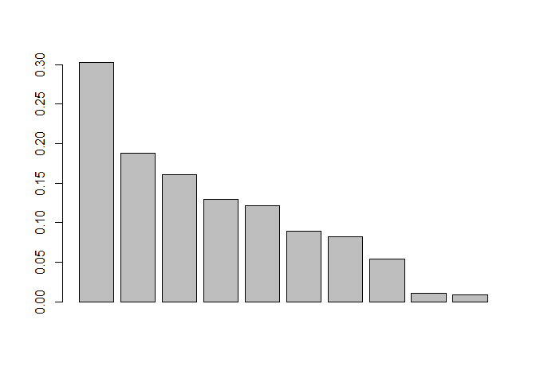

```r
CHI_pca <- pcoa(CHI_vir_jaccard)

# calculate the percentage of variation that each Principle Coordinate accounts for
CHI_Axis1.percent <- CHI_pca$values$Relative_eig[[1]]*100 # Dimension (Axis 1 (PcoA1)) 30.26%
CHI_Axis2.percent <- CHI_pca$values$Relative_eig[[2]]*100 # Dimension (Axis 2 (PcoA2)) 18.78%
CHI_Axis3.percent <- CHI_pca$values$Relative_eig[[3]]*100 #
CHI_Axis4.percent <- CHI_pca$values$Relative_eig[[4]]*100
CHI_Axis5.percent <- CHI_pca$values$Relative_eig[[5]]*100
CHI_Axis6.percent <- CHI_pca$values$Relative_eig[[6]]*100
CHI_Axis7.percent <- CHI_pca$values$Relative_eig[[7]]*100
CHI_Axis8.percent <- CHI_pca$values$Relative_eig[[8]]*100


barplot(CHI_pca$values$Relative_eig[1:10]) #
```

```r
CHI_pca_data <- data.frame(sample = rownames(CHI_pca$vectors),
                                      X = CHI_pca$vectors[, 1],
                                      Y = CHI_pca$vectors[, 2])
```

## adding metadata to PCoA

```r
names(CHI_pca_data)[names(CHI_pca_data)=="sample"] <- "Isolate" # renaming columns so we can merge data.frames
CHI_pca_metadata <- left_join(CHI_pca_data, CHI_isolate_metadata, by = "Isolate")
head(CHI_pca_metadata)
```

```
##                   Isolate          X           Y    study year time_point
## 1 Anhui_China_Zhu_1999_51 0.09363501 -0.05294495 Zhu 2003 1999  1990_1999
## 2 Anhui_China_Zhu_1999_51 0.09363501 -0.05294495 Zhu 2003 1999  1990_1999
## 3 Anhui_China_Zhu_1999_51 0.09363501 -0.05294495 Zhu 2003 1999  1990_1999
## 4 Anhui_China_Zhu_1999_51 0.09363501 -0.05294495 Zhu 2003 1999  1990_1999
## 5 Anhui_China_Zhu_1999_51 0.09363501 -0.05294495 Zhu 2003 1999  1990_1999
## 6 Anhui_China_Zhu_1999_51 0.09363501 -0.05294495 Zhu 2003 1999  1990_1999
```

## Plotting China PCoA data

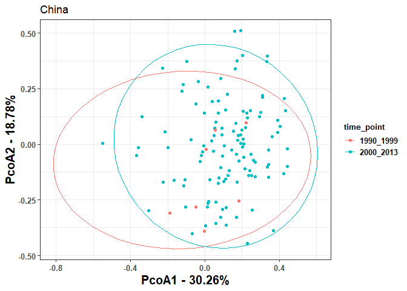

```r
CHI_pcoa_plot <- ggplot(data = CHI_pca_metadata, aes(x = X, y = Y)) +
  geom_point(aes(colour = time_point)) +
  xlab(paste("PcoA1 - ", round(CHI_Axis1.percent,2), "%", sep = "")) +
  ylab(paste("PcoA2 - ", round(CHI_Axis2.percent,2), "%", sep = "")) +
  theme_bw() +
  theme(
    axis.title.x = element_text(face = "bold", size = 15),
    axis.title.y = element_text(face = "bold", size = 15),
    axis.text = element_text(face = "bold", size = 10),
    legend.title = element_text(face = "bold", size = 10),
    legend.text = element_text(face = "bold", size = 10),
    legend.key.size = unit(1, 'lines')
  ) +
  stat_ellipse(aes(x = X, y = Y, color=time_point, group=time_point), level = 0.95) +
  ggtitle("China")

CHI_pcoa_plot
```

## PCOA plots side by side

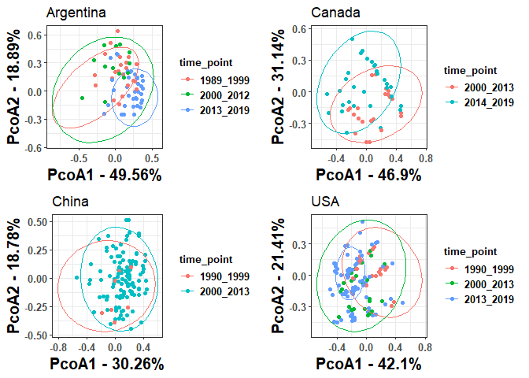

```r
combined_PCOA_temporal <- plot_grid(ARG_pcoa_plot,CAN_pcoa_plot,CHI_pcoa_plot,USA_pcoa_plot)
combined_PCOA_temporal
```